# Barchart futures data

2023-07-08

Show me the money. Time to wrangle Barchart futures data. Let’s see if I can make practice out of theory.

I got a free trial of BarChart and have downloaded some data. Reminders on the month codes: ZCU23 is September 23, ZCZ23 is December 23, ZCH is March 24, ZCK is May.

Check these are good, as I hacked off the last row with some “watermarking” from barchart

```r
zcu23_daily_historical_data_07_08_2023 <- read_csv("zcu23_daily_historical-data-07-08-2023.csv",
     col_types = cols(Time = col_date(format = "%m/%d/%Y")))
zch24_daily_historical_data_07_08_2023 <- read_csv("zch24_daily_historical-data-07-08-2023.csv",
                                                   col_types = cols(Time = col_date(format = "%m/%d/%Y")))
```

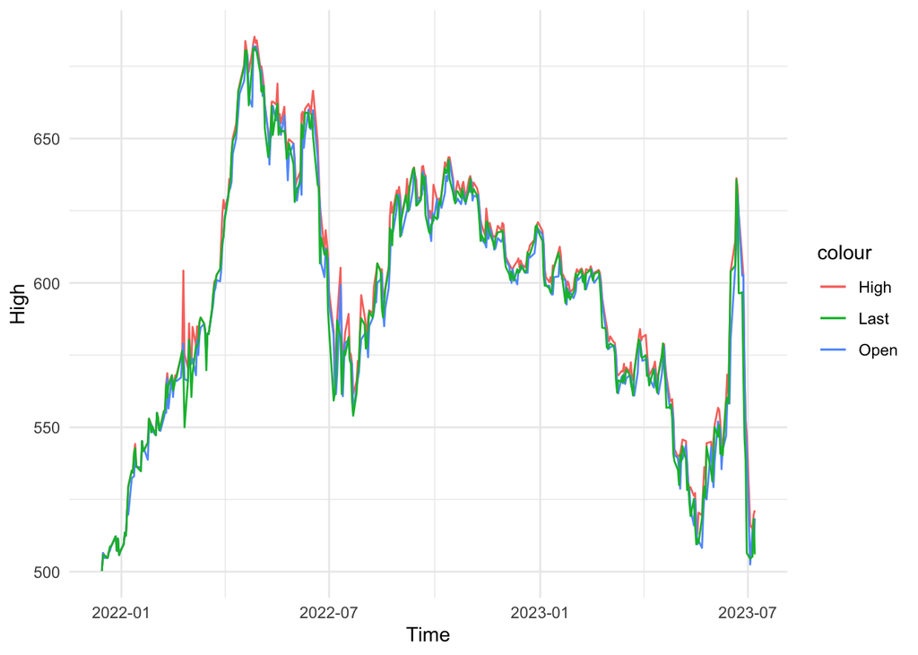

```r
 ggplot(data = zch24_daily_historical_data_07_08_2023, aes(x = Time, y = High, color = "High"))+geom_line()+theme_minimal()+geom_line(aes(x=Time, y= Open, color = "Open"))+geom_line(aes(x=Time, y= Last, color = "Last"))
```

Can compare the two series

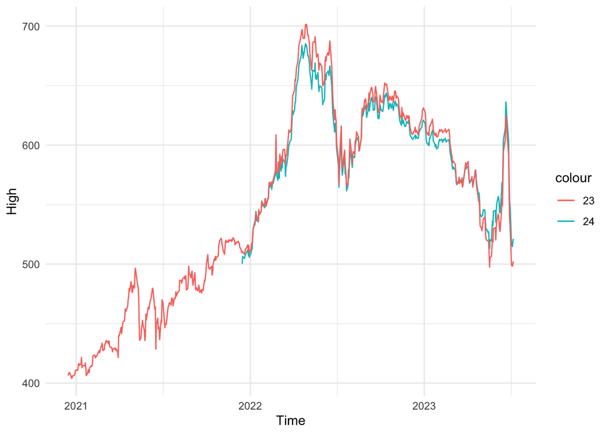

```r
ggplot(data = zch24_daily_historical_data_07_08_2023, aes(x = Time, y = High, color = "24"))+geom_line()+theme_minimal()+geom_line(data = zcu23_daily_historical_data_07_08_2023, aes(x=Time, y = High, color = "23"))
```

Ok, great, as a test case we’re in business. I will download a bunch more stuff. Next to-dos:

- look at the difference between actual corn prices and the next expiring future
- do some options pricing & look at some trades
- move on to value at risk
- make more coffee, it was weak this morning

Before coffee, look at prices!

```r
zcz23_price_history_07_09_2023 <- read_csv("zcz23_price-history-07-09-2023.csv",
    col_types = cols(Time = col_date(format = "%m/%d/%Y")))
```

Let’s plot price history against futures prices. I tried to find the cash price so I can get some proxy for the basis, but Barchart doesn’t explain exactly what I’m getting here with ZCY00. From FarmProgress I can see the basis at particular elevators. How deep do I want to get into this? I’d love to figure out how to set up some bets based on what’ll happen in the freight markets in the fall/winter, but that may be more granular than I can manage here.

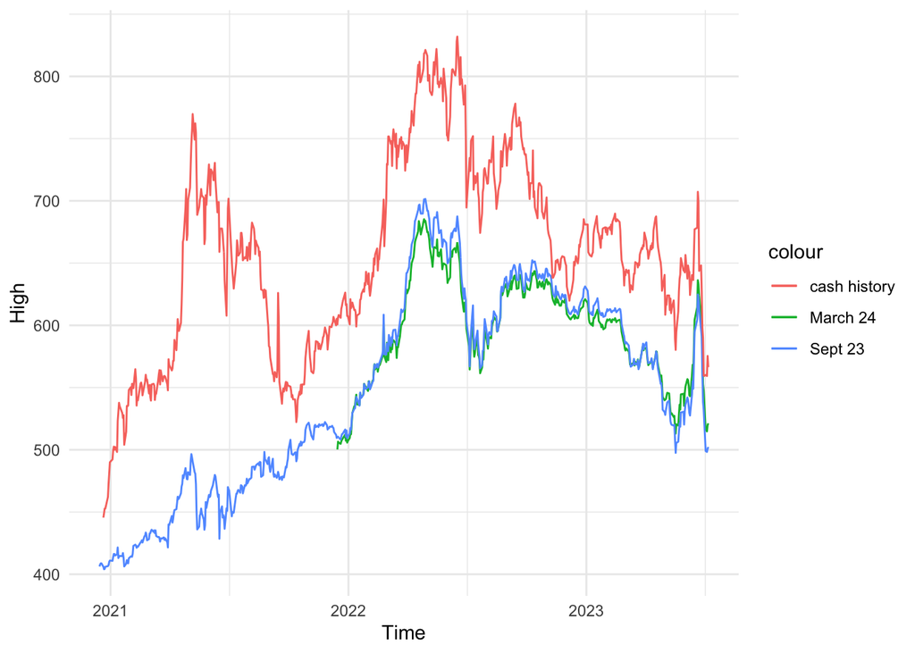

```r
ZCY00_Barchart_Interactive_Chart_Daily_07_09_2023 <- read_csv("ZCY00_Barchart_Interactive_Chart_Daily_07_09_2023.csv",
     col_types = cols(`Date Time` = col_date(format = "%Y-%m-%d")),
     skip = 1)
ggplot(data = zch24_daily_historical_data_07_08_2023, aes(x = Time, y = High, color = "March 24"))+geom_line()+theme_minimal()+geom_line(data = zcu23_daily_historical_data_07_08_2023, aes(x=Time, y = High, color = "Sept 23"))+geom_line(data = ZCY00_Barchart_Interactive_Chart_Daily_07_09_2023, aes(x=`Date Time`, y = High, color = "cash history"))
```